# HW3-IE582

Gulce Karabacak

22 Kasım 2019

# HOMEWORK 3

```r
library(data.table)
library(Metrics)
library(glmnet)
```

## a)

Aim is using 168 and 48 hours ago consumption values as naïve approaches to predict next day’s consumption.

In order to make computations, I convert consumptions to numeric form.

I defined datatables and checked whether there is any null.

```r
test<-fread("C:/Users/test2days.csv")
setnames(test, c("Date_t", "Hour_t","C_t"))

train<-fread("C:/Users/ConsumptionTotalData.csv")
setnames(train, c("Date_Td", "Hour_Td","C_Td"))


test$C_t <- gsub("\\.", "", test$C_t)
test$C_t<- gsub("\\,", ".", test$C_t)
test$C_t<-as.numeric(test$C_t)

train$C_Td <- gsub("\\.", "", train$C_Td)
train$C_Td<- gsub("\\,", ".", train$C_Td)
train$C_Td<-as.numeric(train$C_Td)

sum(is.na(test))
```

```
## [1] 0
```

```r
sum(is.na(train))
```

```
## [1] 0
```

I added predictions to the test data for both type. (lag48 and lag168)

```r
testp48<-cbind(test, train[33529:33576,3])
testp168<-cbind(test, train[33409:33456,3])
```

For each hour, APE is:

```r
testp48$ape<- abs((testp48$C_t-testp48$C_Td)/testp48$C_t)*100
testp168$ape<- abs((testp168$C_t-testp168$C_Td)/testp168$C_t)*100
```

Looked MAPE value for both prediction.

```r
mape48<-mean(testp48$ape)
mape48
```

```
## [1] 4.560622
```

```r
mape168<-mean(testp168$ape)
mape168
```

```
## [1] 1.775085
```

Sİnce we can see from the results, MAPE value of Lag_168 is lower than the value of Lag_48, which means that Lag_168 has better performance in prediction.

## b)

At first, I prepared long format data table for train data.

To be ensure that each data has lag values, I removed first 168 data on the train since they don’t have lag 168 values.

```r
trainwithlag<-train[-c(1:168),]

trainwithlag<-cbind(trainwithlag, train[121:33528,3])
trainwithlag<-cbind(trainwithlag, train[1:33408,3])

colnames(trainwithlag)[3]<-"Consumption"
colnames(trainwithlag)[4]<-"lag_48"
colnames(trainwithlag)[5]<-"lag_168"
```

I trained model with training data and got summary.

```r
linreg<-lm(Consumption~lag_48+lag_168, data = trainwithlag)
summary(linreg)
```

```
##
## Call:
## lm(formula = Consumption ~ lag_48 + lag_168, data = trainwithlag)
##
## Residuals:
##      Min       1Q   Median       3Q      Max
## -16784.6   -994.2      2.9   1022.4  15951.4
##
## Coefficients:
##              Estimate Std. Error t value Pr(>|t|)
## (Intercept) 1.624e+03  9.678e+01   16.78   <2e-16 ***
## lag_48      3.257e-01  3.520e-03   92.51   <2e-16 ***
## lag_168     6.246e-01  3.518e-03  177.51   <2e-16 ***
## ---
## Signif. codes:  0 '***' 0.001 '**' 0.01 '*' 0.05 '.' 0.1 ' ' 1
##
## Residual standard error: 2403 on 33405 degrees of freedom
## Multiple R-squared:  0.7627, Adjusted R-squared:  0.7627
## F-statistic: 5.368e+04 on 2 and 33405 DF,  p-value: < 2.2e-16
```

```r
linreg
```

```
##
## Call:
## lm(formula = Consumption ~ lag_48 + lag_168, data = trainwithlag)
##
## Coefficients:
## (Intercept)       lag_48      lag_168
##   1623.7675       0.3257       0.6246
```

I prepared long format data table for test data.

```r
testwithlag<-cbind(test, testp48[,4])
testwithlag<-cbind(testwithlag, testp168[,4])

colnames(testwithlag)[3]<-"Consumption"
colnames(testwithlag)[4]<-"lag_48"
colnames(testwithlag)[5]<-"lag_168"
```

I tested model on the test data.

```r
testprediction<-predict(linreg, testwithlag)
testwithlag<-cbind(testwithlag, testprediction)
```

Calculated mape.

```r
testwithlag$ape<- abs((testwithlag$Consumption-testwithlag$testprediction)/testwithlag$Consumption)*100

mapepartb<-mean(testwithlag$ape)
mapepartb
```

```
## [1] 2.27582
```

## c)

At first, I seperated training data according to its hours.

```r
setkey(trainwithlag, Hour_Td)

trainh0<-trainwithlag["00:00"]
trainh1<-trainwithlag["01:00"]
trainh2<-trainwithlag["02:00"]
trainh3<-trainwithlag["03:00"]
trainh4<-trainwithlag["04:00"]
trainh5<-trainwithlag["05:00"]
trainh6<-trainwithlag["06:00"]
trainh7<-trainwithlag["07:00"]
trainh8<-trainwithlag["08:00"]
trainh9<-trainwithlag["09:00"]
trainh10<-trainwithlag["10:00"]
trainh11<-trainwithlag["11:00"]
trainh12<-trainwithlag["12:00"]
trainh13<-trainwithlag["13:00"]
trainh14<-trainwithlag["14:00"]
trainh15<-trainwithlag["15:00"]
trainh16<-trainwithlag["16:00"]
trainh17<-trainwithlag["17:00"]
trainh18<-trainwithlag["18:00"]
trainh19<-trainwithlag["19:00"]
trainh20<-trainwithlag["20:00"]
trainh21<-trainwithlag["21:00"]
trainh22<-trainwithlag["22:00"]
trainh23<-trainwithlag["23:00"]
```

I seperated test data according to its hours.

```r
testwithlag<-as.data.table(testwithlag)
setkey(testwithlag, Hour_t)

testh0<-testwithlag["00:00"]
testh1<-testwithlag["01:00"]
testh2<-testwithlag["02:00"]
testh3<-testwithlag["03:00"]
testh4<-testwithlag["04:00"]
testh5<-testwithlag["05:00"]
testh6<-testwithlag["06:00"]
testh7<-testwithlag["07:00"]
testh8<-testwithlag["08:00"]
testh9<-testwithlag["09:00"]
testh10<-testwithlag["10:00"]
testh11<-testwithlag["11:00"]
testh12<-testwithlag["12:00"]
testh13<-testwithlag["13:00"]
testh14<-testwithlag["14:00"]
testh15<-testwithlag["15:00"]
testh16<-testwithlag["16:00"]
testh17<-testwithlag["17:00"]
testh18<-testwithlag["18:00"]
testh19<-testwithlag["19:00"]
testh20<-testwithlag["20:00"]
testh21<-testwithlag["21:00"]
testh22<-testwithlag["22:00"]
testh23<-testwithlag["23:00"]
```

I trained 24 models with training data and used in test data, got Mape values.

```r
trainhlist<-list(trainh0,trainh1,trainh2,trainh3,trainh4,trainh5,trainh6,trainh7,trainh8,trainh9,trainh10,trainh11,trainh12,trainh13,trainh14,trainh15,trainh16,trainh17,trainh18,trainh19,trainh20,trainh21,trainh22,trainh23)

testhlist<-list(testh0,testh1,testh2,testh3,testh4,testh5,testh6,testh7,testh8,testh9,testh10,testh11,testh12,testh13,testh14,testh15,testh16,testh17,testh18,testh19,testh20,testh21,testh22,testh23)

linreg<-vector(mode = "list", length = 24)
testpredc<-vector(mode = "list", length = 24)
Ape_partc<-vector(mode = "list", length = 24)
Apec<-vector(mode = "list", length = 24)

for (i in 1:24) {
linreg[[i]]<-lm(Consumption~lag_48+lag_168, data = trainhlist[[i]])

testpredc[[i]]<-predict(linreg[[i]], testhlist[[i]])

Ape_partc[[i]]<-abs((testhlist[[i]][["Consumption"]]-testpredc[[i]])/testhlist[[i]][["Consumption"]])*100
Apec[[i]]<-mean(Ape_partc[[i]])

}
```

## d)

Construction of wide format features for train data is done. (For all hours of the same day, features are the same also in this model. So, for each day, I found feature data table.)

```r
trainford<-data.table(matrix(nrow = 1392))

for (k in 8:1399) {

    for(i in 1:24){
  trainford[k, paste0("lag_48h", i)]   <- train[i+24*k-72,3]
    }
    for(i in 1:24){
 trainford[k, paste0("lag_168h", i)]   <- train[i+24*k-192,3]
    }

}

trainford[,V1:=NULL]
trainford<-tail(trainford,-7)
```

Construction of wide format for test data is done.

```r
testford<-data.table(matrix(nrow = 2))

for (k in 1:2) {



    for(i in 1:24){
  testford[k, paste0("lag_48h", i)]   <- train[33504+i+24*k,3]
    }
    for(i in 1:24){
  testford[k, paste0("lag_168h", i)]   <- train[33384+i+24*k,3]
    }



}
testford[,V1:=NULL]
```

```r
traind<-train[-c(1:336),]
setkey(traind, Hour_Td)

dtrainh0<-cbind(traind["00:00"],trainford)
dtrainh1<-cbind(traind["00:00"],trainford)
dtrainh2<-cbind(traind["00:00"],trainford)
dtrainh3<-cbind(traind["00:00"],trainford)
dtrainh4<-cbind(traind["00:00"],trainford)
dtrainh5<-cbind(traind["00:00"],trainford)
dtrainh6<-cbind(traind["00:00"],trainford)
dtrainh7<-cbind(traind["00:00"],trainford)
dtrainh8<-cbind(traind["00:00"],trainford)
dtrainh9<-cbind(traind["00:00"],trainford)
dtrainh10<-cbind(traind["00:00"],trainford)
dtrainh11<-cbind(traind["00:00"],trainford)
dtrainh12<-cbind(traind["00:00"],trainford)
dtrainh13<-cbind(traind["00:00"],trainford)
dtrainh14<-cbind(traind["00:00"],trainford)
dtrainh15<-cbind(traind["00:00"],trainford)
dtrainh16<-cbind(traind["00:00"],trainford)
dtrainh17<-cbind(traind["00:00"],trainford)
dtrainh18<-cbind(traind["00:00"],trainford)
dtrainh19<-cbind(traind["00:00"],trainford)
dtrainh20<-cbind(traind["00:00"],trainford)
dtrainh21<-cbind(traind["00:00"],trainford)
dtrainh22<-cbind(traind["00:00"],trainford)
dtrainh23<-cbind(traind["00:00"],trainford)


setkey(test, Hour_t)

dtesth0<-cbind(test["00:00"],testford)
dtesth1<-cbind(test["00:00"],testford)
dtesth2<-cbind(test["00:00"],testford)
dtesth3<-cbind(test["00:00"],testford)
dtesth4<-cbind(test["00:00"],testford)
dtesth5<-cbind(test["00:00"],testford)
dtesth6<-cbind(test["00:00"],testford)
dtesth7<-cbind(test["00:00"],testford)
dtesth8<-cbind(test["00:00"],testford)
dtesth9<-cbind(test["00:00"],testford)
dtesth10<-cbind(test["00:00"],testford)
dtesth11<-cbind(test["00:00"],testford)
dtesth12<-cbind(test["00:00"],testford)
dtesth13<-cbind(test["00:00"],testford)
dtesth14<-cbind(test["00:00"],testford)
dtesth15<-cbind(test["00:00"],testford)
dtesth16<-cbind(test["00:00"],testford)
dtesth17<-cbind(test["00:00"],testford)
dtesth18<-cbind(test["00:00"],testford)
dtesth19<-cbind(test["00:00"],testford)
dtesth20<-cbind(test["00:00"],testford)
dtesth21<-cbind(test["00:00"],testford)
dtesth22<-cbind(test["00:00"],testford)
dtesth23<-cbind(test["00:00"],testford)
```

Penalized regression models are trained and tested for each hours. Mape values are calculated.

```r
dtrainhlist<-list(dtrainh0,dtrainh1,dtrainh2,dtrainh3,dtrainh4,dtrainh5,dtrainh6,dtrainh7,dtrainh8,dtrainh9,dtrainh10,dtrainh11,dtrainh12,dtrainh13,dtrainh14,dtrainh15,dtrainh16,dtrainh17,dtrainh18,dtrainh19,dtrainh20,dtrainh21,dtrainh22,dtrainh23)

dtesthlist<-list(dtesth0,dtesth1,dtesth2,dtesth3,dtesth4,dtesth5,dtesth6,dtesth7,dtesth8, dtesth9,dtesth10,dtesth11,dtesth12,dtesth13,dtesth14,dtesth15,dtesth16,dtesth17,dtesth18,dtesth19,dtesth20,dtesth21,dtesth22,dtesth23)

prediction_partd<-vector(mode = "list", length = 24)
Ape_partd<-vector(mode = "list", length = 24)
ApeD<-vector(mode = "list", length = 24)
x<-as.matrix(trainford)
y<-as.matrix(testford)

for(i in 1:24 ) {

penreg<-cv.glmnet(x, dtrainhlist[[i]][["C_Td"]], nfolds=10)

z<-glmnet(x,dtrainhlist[[i]][["C_Td"]],lambda = penreg$lambda.min)

prediction_partd[[i]]<-predict(z,y)


Ape_partd[[i]]<-abs((dtesthlist[[i]][["C_t"]]-prediction_partd[[i]])/dtesthlist[[i]][["C_t"]])*100
ApeD[[i]]<-mean(Ape_partd[[i]])

}
```

## f)

All models are plotted.

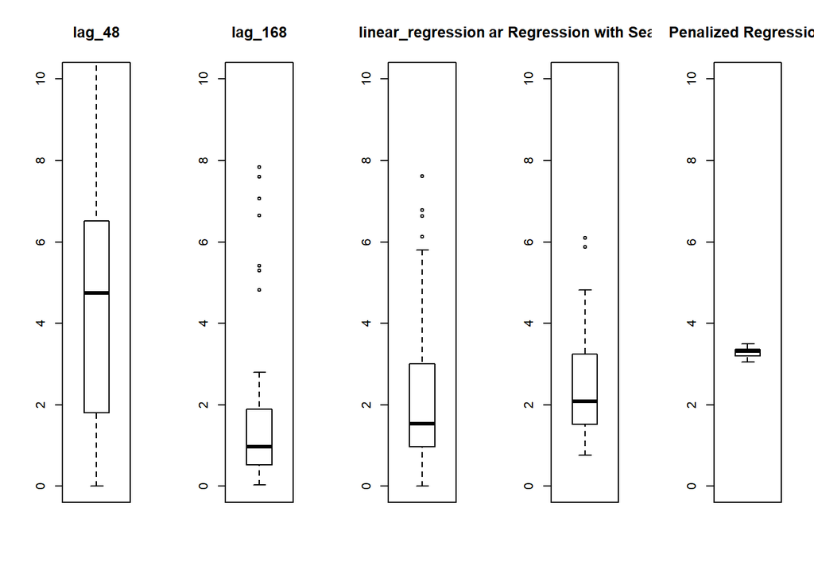

```r
par(mfrow=c(1,5))
boxplot(testp48$ape, main="lag_48", ylim=c(0,10))
boxplot(testp168$ape,main="lag_168", ylim=c(0,10))
boxplot(testwithlag$ape,main="linear_regression", ylim=c(0,10))
boxplot(as.numeric(Apec),main="Linear Regression with Seasonality", ylim=c(0,10))
boxplot(as.numeric(ApeD), main="Penalized Regression", ylim=c(0,10))
```

As it can be seen from boxplots, model with lag_48 has high median and wide range which means high variance. That is not a preferrable one generally and it is an expected result since electric consumption changes from day to day within week. (weekday, weekend etc.) Model with lag_168 has low median and low variance which are good attributes, however it has a lot of outlier that means the model is weak to explain all of data. Linear regression model has higher median and variance than the model with lag_168 however less outliers. Regression for each hour (with hourly seasonality) provides lower variance than linear regression as expected.However, error median of linear regression is lower. In general, the best model in terms of variability is penalized regression model with lowest range. However, it is better to look at last two models for each hour separately since they has separate models for each hour.

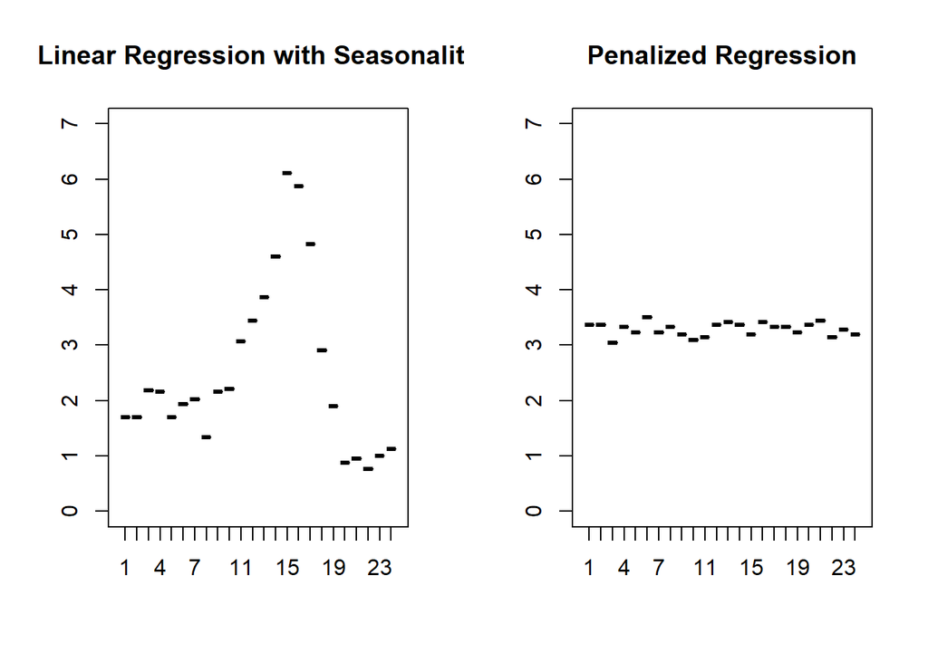

```r
  par(mfrow=c(1,2))
boxplot(Apec,main="Linear Regression with Seasonality", ylim=c(0,7))
boxplot(ApeD, main="Penalized Regression", ylim=c(0,7))
```